# Applied Machine Learning

```r
#########################################################################################
### GES implementation
get_ges_weights = function(selected, learner_num_ids) {
  selected = selected[selected != 0]
  n = length(selected)
  weights = map_dbl(learner_num_ids, function(learner_num_id) {
    sum(learner_num_id == selected) / n
  })
  weights
}

ges = function(learner_preds, iterations = 100L, measure = msr("classif.auc")) {
  iteration = 0
  learner_num_ids = seq_along(learner_preds)
  performance = numeric(iterations)
  selected = integer(iterations)
  for (iteration in seq_len(iterations)) {
    cat("Iteration: ", iteration, "\n")
    performance_tmp = map_dbl(learner_num_ids, function(learner_num_id) {
      selected_tmp = selected
      selected_tmp[iteration] = learner_num_id
      weights = get_ges_weights(selected_tmp, learner_num_ids = learner_num_ids)
      performances = map_dbl(seq_len(k), function(fold) {
        learner_ps = map(learner_preds, function(learner_pred) learner_pred$predictions()[[fold]])
        row_ids = learner_ps[[1L]]$row_ids
        stopifnot(all(map_lgl(learner_ps[-1L], function(learner_p) all(learner_p$row_ids == row_ids))))
        truth = learner_ps[[1L]]$truth
        weighted_probs = Reduce("+", mapply(FUN = function(prob, weight) prob * weight, map(learner_ps, function(learner_p) learner_p$prob), as.list(weights), SIMPLIFY = FALSE))
        stopifnot(all.equal(rowSums(weighted_probs),  rep(1, nrow(weighted_probs))))
        weighted_response = colnames(weighted_probs)[apply(weighted_probs, MARGIN = 1L, FUN = which.max)]
        weighted_p = PredictionClassif$new(row_ids = row_ids, truth = truth, response = weighted_response, prob = weighted_probs)
        weighted_p$score(measure)
      })
      mean(performances)
    })
    cat("Performance if learner added: ", round(performance_tmp, 3), "\n")
    if (!measure$minimize) {
      performance_tmp = - performance_tmp
    }
    select = which.min(performance_tmp)
    performance[iteration] = performance_tmp[select]
    selected[iteration] = select
  }
  best_iteration = which.min(performance)
  weights = get_ges_weights(selected[seq_len(best_iteration)], learner_num_ids = learner_num_ids)
  if (!measure$minimize) {
    performance = - performance
  }
  list(best_iteration = best_iteration, performance_best = performance[best_iteration], weights = weights, selected = selected, performance = performance)
}

ges_results = ges(list(dt_pred, kknn_pred, log_reg_pred))
## Iteration:  1
## Performance if learner added:  0.715 0.695 0.759
## Iteration:  2
## Performance if learner added:  0.773 0.758 0.759
## Iteration:  3
## Performance if learner added:  0.772 0.771 0.773
## Iteration:  4
## Performance if learner added:  0.773 0.774 0.771
## Iteration:  5
## Performance if learner added:  0.776 0.769 0.775
## Iteration:  6
## Performance if learner added:  0.776 0.771 0.776
## Iteration:  7
## Performance if learner added:  0.778 0.773 0.778
## Iteration:  8
## Performance if learner added:  0.777 0.774 0.777
## Iteration:  9
## Performance if learner added:  0.777 0.776 0.777
## Iteration:  10
## Performance if learner added:  0.777 0.776 0.777
## Iteration:  11
## Performance if learner added:  0.776 0.777 0.776
## Iteration:  12
## Performance if learner added:  0.777 0.774 0.776
## Iteration:  13
## Performance if learner added:  0.776 0.775 0.776
## Iteration:  14
## Performance if learner added:  0.778 0.776 0.776
## Iteration:  15
## Performance if learner added:  0.776 0.776 0.776
## Iteration:  16
## Performance if learner added:  0.777 0.777 0.777
## Iteration:  17
## Performance if learner added:  0.777 0.775 0.777
## Iteration:  18
## Performance if learner added:  0.776 0.775 0.777
## Iteration:  19
## Performance if learner added:  0.778 0.776 0.777
## Iteration:  20
## Performance if learner added:  0.776 0.776 0.777
## Iteration:  21
## Performance if learner added:  0.778 0.777 0.776
## Iteration:  22
## Performance if learner added:  0.776 0.776 0.777
## Iteration:  23
## Performance if learner added:  0.777 0.777 0.777
## Iteration:  24
## Performance if learner added:  0.777 0.777 0.777
## Iteration:  25
## Performance if learner added:  0.777 0.777 0.777
## Iteration:  26
## Performance if learner added:  0.778 0.777 0.776
## Iteration:  27
## Performance if learner added:  0.777 0.776 0.777
## Iteration:  28
## Performance if learner added:  0.778 0.776 0.777
## Iteration:  29
## Performance if learner added:  0.777 0.777 0.777
## Iteration:  30
## Performance if learner added:  0.777 0.777 0.776
## Iteration:  31
## Performance if learner added:  0.778 0.777 0.776
## Iteration:  32
## Performance if learner added:  0.777 0.776 0.777
## Iteration:  33
## Performance if learner added:  0.778 0.776 0.777
## Iteration:  34
## Performance if learner added:  0.777 0.777 0.777
## Iteration:  35
## Performance if learner added:  0.776 0.777 0.778
## Iteration:  36
## Performance if learner added:  0.777 0.777 0.777
## Iteration:  37
## Performance if learner added:  0.778 0.776 0.777
## Iteration:  38
## Performance if learner added:  0.776 0.776 0.778
## Iteration:  39
## Performance if learner added:  0.778 0.777 0.777
## Iteration:  40
## Performance if learner added:  0.776 0.777 0.778
## Iteration:  41
## Performance if learner added:  0.777 0.777 0.777
## Iteration:  42
## Performance if learner added:  0.778 0.777 0.777
## Iteration:  43
## Performance if learner added:  0.776 0.778 0.777
## Iteration:  44
## Performance if learner added:  0.778 0.776 0.777
## Iteration:  45
## Performance if learner added:  0.777 0.777 0.778
## Iteration:  46
## Performance if learner added:  0.778 0.777 0.777
## Iteration:  47
## Performance if learner added:  0.777 0.777 0.778
## Iteration:  48
## Performance if learner added:  0.777 0.777 0.778
## Iteration:  49
## Performance if learner added:  0.778 0.777 0.777
## Iteration:  50
## Performance if learner added:  0.777 0.778 0.777
## Iteration:  51
## Performance if learner added:  0.778 0.777 0.778
## Iteration:  52
## Performance if learner added:  0.777 0.777 0.778
## Iteration:  53
## Performance if learner added:  0.778 0.777 0.778
## Iteration:  54
## Performance if learner added:  0.777 0.777 0.778
## Iteration:  55
## Performance if learner added:  0.777 0.777 0.778
## Iteration:  56
## Performance if learner added:  0.778 0.777 0.777
## Iteration:  57
## Performance if learner added:  0.777 0.778 0.778
## Iteration:  58
## Performance if learner added:  0.778 0.777 0.778
## Iteration:  59
## Performance if learner added:  0.778 0.777 0.777
## Iteration:  60
## Performance if learner added:  0.778 0.777 0.778
## Iteration:  61
## Performance if learner added:  0.777 0.777 0.777
## Iteration:  62
## Performance if learner added:  0.777 0.777 0.778
## Iteration:  63
## Performance if learner added:  0.778 0.777 0.777
## Iteration:  64
## Performance if learner added:  0.777 0.777 0.778
## Iteration:  65
## Performance if learner added:  0.778 0.777 0.778
## Iteration:  66
## Performance if learner added:  0.778 0.778 0.777
## Iteration:  67
## Performance if learner added:  0.778 0.777 0.777
## Iteration:  68
## Performance if learner added:  0.777 0.778 0.777
## Iteration:  69
## Performance if learner added:  0.778 0.777 0.778
## Iteration:  70
## Performance if learner added:  0.777 0.777 0.778
## Iteration:  71
## Performance if learner added:  0.777 0.777 0.778
## Iteration:  72
## Performance if learner added:  0.778 0.777 0.778
## Iteration:  73
## Performance if learner added:  0.777 0.777 0.778
## Iteration:  74
## Performance if learner added:  0.778 0.777 0.777
## Iteration:  75
## Performance if learner added:  0.777 0.777 0.777
## Iteration:  76
## Performance if learner added:  0.778 0.777 0.778
## Iteration:  77
## Performance if learner added:  0.777 0.777 0.778
## Iteration:  78
## Performance if learner added:  0.778 0.777 0.778
## Iteration:  79
## Performance if learner added:  0.778 0.777 0.777
## Iteration:  80
## Performance if learner added:  0.777 0.778 0.778
## Iteration:  81
## Performance if learner added:  0.778 0.778 0.777
## Iteration:  82
## Performance if learner added:  0.777 0.778 0.777
## Iteration:  83
## Performance if learner added:  0.778 0.777 0.778
## Iteration:  84
## Performance if learner added:  0.777 0.777 0.778
## Iteration:  85
## Performance if learner added:  0.778 0.777 0.778
## Iteration:  86
## Performance if learner added:  0.778 0.778 0.778
## Iteration:  87
## Performance if learner added:  0.777 0.778 0.778
## Iteration:  88
## Performance if learner added:  0.777 0.778 0.777
## Iteration:  89
## Performance if learner added:  0.778 0.777 0.778
## Iteration:  90
## Performance if learner added:  0.778 0.777 0.778
## Iteration:  91
## Performance if learner added:  0.778 0.777 0.778
## Iteration:  92
## Performance if learner added:  0.778 0.778 0.778
## Iteration:  93
## Performance if learner added:  0.777 0.777 0.778
## Iteration:  94
## Performance if learner added:  0.778 0.778 0.778
## Iteration:  95
## Performance if learner added:  0.777 0.778 0.777
## Iteration:  96
## Performance if learner added:  0.778 0.777 0.778
## Iteration:  97
## Performance if learner added:  0.778 0.778 0.778
## Iteration:  98
## Performance if learner added:  0.778 0.777 0.778
## Iteration:  99
## Performance if learner added:  0.778 0.778 0.778
## Iteration:  100
## Performance if learner added:  0.777 0.778 0.778

# configure the ensemble with the optimized weights and evaluate on the outer split
grl_weights_optimized_ges = grl$clone(deep = TRUE)
grl_weights_optimized_ges$param_set$set_values(.values = list(classifavg.weights = ges_results$weights))
grl_weights_optimized_ges$id = paste0(grl_weights_optimized_ges$id, ".optimized_ges")
#########################################################################################
```

```r
bg = benchmark_grid(task, list(grl, grl_weights_optimized_cmaes, grl_weights_optimized_ges, dt, kknn, log_reg, featureless), outer_split)
b = benchmark(bg)
b$aggregate(msr("classif.auc"))
```

```
##    nr       task_id                                                            learner_id resampling_id iters
## 1:  1 german_credit                 classif.rpart.classif.kknn.classif.log_reg.classifavg       holdout     1
## 2:  2 german_credit classif.rpart.classif.kknn.classif.log_reg.classifavg.optimized_cmaes       holdout     1
## 3:  3 german_credit   classif.rpart.classif.kknn.classif.log_reg.classifavg.optimized_ges       holdout     1
## 4:  4 german_credit                                                         classif.rpart       holdout     1
## 5:  5 german_credit                                                          classif.kknn       holdout     1
## 6:  6 german_credit                                                       classif.log_reg       holdout     1
## 7:  7 german_credit                                                   classif.featureless       holdout     1
##    classif.auc
## 1:   0.7827757
## 2:   0.7877689
## 3:   0.7874274
## 4:   0.7139809
## 5:   0.6948831
## 6:   0.7800017
## 7:   0.5000000
## Hidden columns: resample_result
```

```r
# compare the weights
grl_weights_optimized_cmaes$param_set$get_values()[["classifavg.weights"]]
```

```
##      w_dt    w_kknn w_log_reg
## 0.4222587 0.1554825 0.4222587
```

```r
grl_weights_optimized_ges$param_set$get_values()[["classifavg.weights"]]
```

```
## [1] 0.4285714 0.1530612 0.4183673
```

We already discussed that GES effectively optimizes weights on an integer scale. CMA-ES in contrast can overfit to the validation data. In this example, both performed well with respect to generalization performance. For some more background, see, e.g., https://arxiv.org/pdf/2307.00286

# 2 Single- and Multilayer Stacking

## 2.1 Level 0

Proceed to benchmark the stacked ensemble against each level 0 learner and the random forest. Use 5-fold CV to evaluate the ROC AUC of the models.

**Hint 1:**

To wrap a learner within an ensemble and use its predictions, the learner_cv `PipeOp` is essential. Its `resampling.method` hyperparameter allows you to cross-validate the predictions or not. Similarly `resampling.folds` allows you to specify the number of folds if predictions should be cross-validated. To combine the level 0 output, use the featureunion `PipeOp`. The following gallery post is helpful: https://mlr-org.com/gallery/pipelines/2020-04-27-tuning-stacking/index.html

**Hint 2:**

```r
resampling = rsmp("cv", folds = ...)$instantiate(task)
dt = lrn("classif.rpart")
dt$predict_type = "prob"
kknn = lrn(..., k = ...)
kknn$predict_type = "prob"
elnet = lrn(..., alpha = ..., s = ...)
elnet$predict_type = "prob"
elnet = as_learner(po(...) %>>% ...)
naive_bayes = lrn(...)
naive_bayes$predict_type = "prob"
naive_bayes = as_learner(po(...) %>>% ...)
xgboost = lrn(..., nrounds = ...)
xgboost = as_learner(po(...) %>>% ...)
xgboost$predict_type = "prob"
rf = lrn(..., num.trees = ..._
rf$predict_type = "prob"

level0 = gunion(
  list(
    po("learner_cv", learner = ..., resampling.method = ...),
    ...
  )
) %>>% po(...)
level0$plot()

level0_train_output = level0$train(task)
level0_train_output

level1 = lrn(..., id = "log_reg_out")
level1$predict_type = "prob"

ensemble = as_learner(level0 %>>% level1)
ensemble$id = "Simple Stacked Ensemble Insample"
ensemble$graph$plot()

bg = benchmark_grid(..., list(...), ...)
b = benchmark(bg)
autoplot(..., measure = ...)
```

### Solution:

**Click me:**

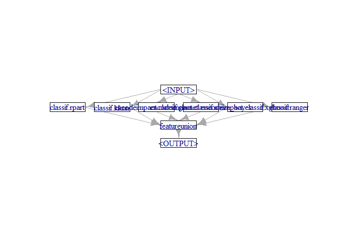

```r
resampling = rsmp("cv", folds = 5L)$instantiate(task)
dt = lrn("classif.rpart")
dt$predict_type = "prob"
kknn = lrn("classif.kknn", k = 7L)
kknn$predict_type = "prob"
elnet = lrn("classif.glmnet", alpha = 0.5, s = 0.01)
elnet$predict_type = "prob"
elnet = as_learner(po("encodeimpact") %>>% elnet)
naive_bayes = lrn("classif.naive_bayes")
naive_bayes$predict_type = "prob"
naive_bayes = as_learner(po("encodeimpact") %>>% naive_bayes)
xgboost = lrn("classif.xgboost", nrounds = 100L)
xgboost = as_learner(po("encodeimpact") %>>% xgboost)
xgboost$predict_type = "prob"
rf = lrn("classif.ranger", num.trees = 100L)
rf$predict_type = "prob"

level0 = gunion(
  list(
    po("learner_cv", learner = dt, resampling.method = "insample"),
    po("learner_cv", learner = kknn, resampling.method = "insample"),
    po("learner_cv", learner = elnet, resampling.method = "insample"),
    po("learner_cv", learner = naive_bayes, resampling.method = "insample"),
    po("learner_cv", learner = xgboost, resampling.method = "insample"),
    po("learner_cv", learner = rf, resampling.method = "insample")
  )
) %>>% po("featureunion")
level0$plot()
```

```r
level0_train_output = level0$train(task)
level0_train_output
```

```
## $featureunion.output
## <TaskClassif:german_credit> (1000 x 13): German Credit
## * Target: credit_risk
## * Properties: twoclass
## * Features (12):
##   - dbl (12): classif.kknn.prob.bad, classif.kknn.prob.good, classif.ranger.prob.bad,
##     classif.ranger.prob.good, classif.rpart.prob.bad, classif.rpart.prob.good,
##     encodeimpact.classif.glmnet.prob.bad, encodeimpact.classif.glmnet.prob.good,
##     encodeimpact.classif.naive_bayes.prob.bad, encodeimpact.classif.naive_bayes.prob.good,
##     encodeimpact.classif.xgboost.prob.bad, encodeimpact.classif.xgboost.prob.good
```

This is a task that contains the probability predictions for each class from each learner. To also have the predicted class, we could set the `resampling.keep_response` of the learner_cv `PipeOp`.

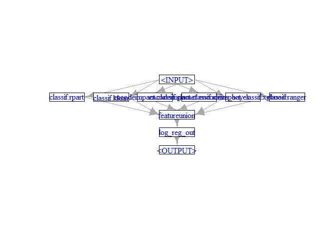

```r
level1 = lrn("classif.log_reg", id = "log_reg_out")
level1$predict_type = "prob"

ensemble = as_learner(level0 %>>% level1)
ensemble$id = "Simple Stacked Ensemble Insample"
ensemble$graph$plot()
```

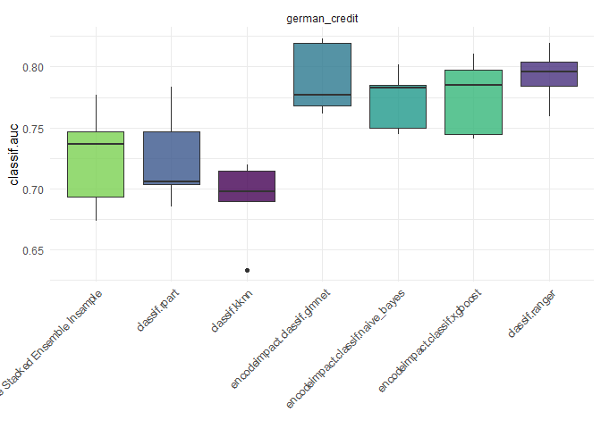

```r
bg = benchmark_grid(task, list(ensemble, dt, kknn, elnet, naive_bayes, xgboost, rf), resampling)
b = benchmark(bg)
autoplot(b, measure = msr("classif.auc"))
```

## 2.2 Cross Validation

So far, we have not cross-validated the level 0 predictions. Create another stacked ensemble where you use 3-fold CV to cross-validate the level 0 predictions.

Proceed to benchmark the cross-validated stacked ensemble against the stacked ensemble, and the random forest. Use 5-fold CV to evaluate the ROC AUC of the models.

**Hint 1:**

You can essentially reuse most of your logic on how to build the graph from the previous exercise. To wrap a learner within an ensemble and use its predictions, the learner_cv `PipeOp` is essential. Have a look at its `resampling.method` parameter to see how to cross-validate level 0 predictions.

**Hint 2:**

```r
level0 = gunion(
  list(
    po("learner_cv", learner = dt, resampling.method = "cv", resampling.folds = 3L),
    .
    .
    .
  )
) %>>% po("featureunion")

ensemble_cv = as_learner(level0 %>>% level1)
ensemble_cv$id = "Simple Stacked Ensemble 3-fold CV"

bg = benchmark_grid(...)
b = benchmark(...)
autoplot(...)
```

### Solution:

**Click me:**

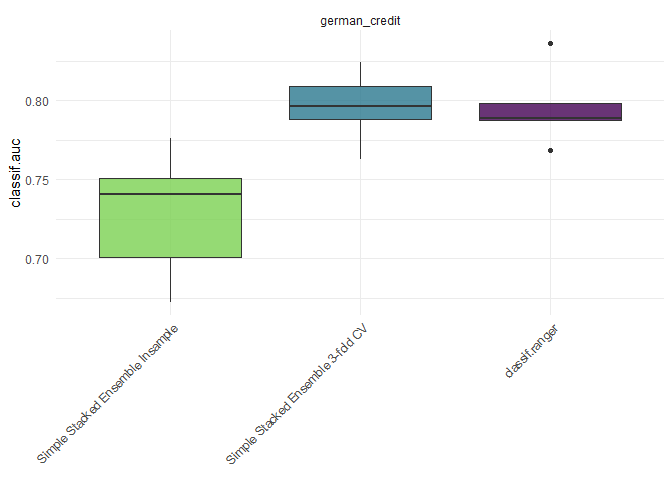

```r
level0 = gunion(
  list(
    po("learner_cv", learner = dt, resampling.method = "cv", resampling.folds = 3L),
    po("learner_cv", learner = kknn, resampling.method = "cv", resampling.folds = 3L),
    po("learner_cv", learner = elnet, resampling.method = "cv", resampling.folds = 3L),
    po("learner_cv", learner = naive_bayes, resampling.method = "cv", resampling.folds = 3L),
    po("learner_cv", learner = xgboost, resampling.method = "cv", resampling.folds = 3L),
    po("learner_cv", learner = rf, resampling.method = "cv", resampling.folds = 3L)
  )
) %>>% po("featureunion")

ensemble_cv = as_learner(level0 %>>% level1)
ensemble_cv$id = "Simple Stacked Ensemble 3-fold CV"

bg = benchmark_grid(task, list(ensemble, ensemble_cv, rf), resampling)
b = benchmark(bg)
autoplot(b, measure = msr("classif.auc"))
```

## 2.3 Add the Original Features of the Task

So far we have dropped the original features of the task. Create another stacked ensemble where you additionally keep the original features of the task. Similarly to before, cross-validate the level 0 predictions.

Proceed to benchmark the cross-validated stacked ensemble with features passed through against the cross-validated stacked ensemble, stacked ensemble, and the random forest. Use 5-fold CV to evaluate the ROC AUC of the models.

**Hint 1:**

You can essentially reuse most of your logic on how to build the graph from the previous exercise. To keep the original features of the task in the output of level 0, use the nop `PipeOp` along the learners.

**Hint 2:**

```r
level0 = gunion(
  list(
    po("learner_cv", learner = dt, resampling.method = "cv", resampling.folds = 3L),
    ...
    po("nop")
  )
) %>>% po("featureunion")
level0_train_output = level0$train(task)[[1L]]
level0_train_output
# The task now also contains the original features of the task passed through

ensemble_cv_pass = as_learner(level0 %>>% level1)
ensemble_cv_pass$id = "Simple Stacked Ensemble 3-fold CV + Orig Features"

bg = benchmark_grid(...)
b = benchmark(...)
autoplot(...)
```

### Solution:

**Click me:**

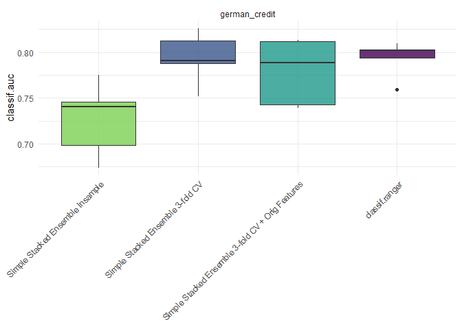

```r
level0 = gunion(
  list(
    po("learner_cv", learner = dt, resampling.method = "cv", resampling.folds = 3L),
    po("learner_cv", learner = kknn, resampling.method = "cv", resampling.folds = 3L),
    po("learner_cv", learner = elnet, resampling.method = "cv", resampling.folds = 3L),
    po("learner_cv", learner = naive_bayes, resampling.method = "cv", resampling.folds = 3L),
    po("learner_cv", learner = xgboost, resampling.method = "cv", resampling.folds = 3L),
    po("learner_cv", learner = rf, resampling.method = "cv", resampling.folds = 3L),
    po("nop")
  )
) %>>% po("featureunion")
level0_train_output = level0$train(task)[[1L]]
level0_train_output
## <TaskClassif:german_credit> (1000 x 33): German Credit
## * Target: credit_risk
## * Properties: twoclass
## * Features (32):
##   - fct (14): credit_history, employment_duration, foreign_worker, housing, job, other_debtors,
##     other_installment_plans, people_liable, personal_status_sex, property, purpose, savings, status,
##     telephone
##   - dbl (12): classif.kknn.prob.bad, classif.kknn.prob.good, classif.ranger.prob.bad,
##     classif.ranger.prob.good, classif.rpart.prob.bad, classif.rpart.prob.good,
##     encodeimpact.classif.glmnet.prob.bad, encodeimpact.classif.glmnet.prob.good,
##     encodeimpact.classif.naive_bayes.prob.bad, encodeimpact.classif.naive_bayes.prob.good,
##     encodeimpact.classif.xgboost.prob.bad, encodeimpact.classif.xgboost.prob.good
##   - int (3): age, amount, duration
##   - ord (3): installment_rate, number_credits, present_residence
# The task now also contains the original features of the task passed through

ensemble_cv_pass = as_learner(level0 %>>% level1)
ensemble_cv_pass$id = "Simple Stacked Ensemble 3-fold CV + Orig Features"

bg = benchmark_grid(task, list(ensemble, ensemble_cv, ensemble_cv_pass, rf), resampling)
b = benchmark(bg)
autoplot(b, measure = msr("classif.auc"))
```

Usefulness of passing through the original features of the task usually strongly depends on the higher level learners. If you have time, you may want to play around with the choice of the level 1 learner (or optimize it directly).

## 2.4 Multilayer Stacking Ensemple

Finally, create a multi-layer stacking ensemble by passing the output of the current level 0 into a level 1 that is built similar as level 1. Similarly to before, keep the original features of the task and cross-validate the level 0 and level 1 predictions. Then use a logistic regression on the final level 2. Make sure that when you pass the original features of the task to the final level 2 that you do not also pass the cross-validated predictions from level 1.

Proceed to benchmark the this cross-validated multi-layer stacked ensemble with features passed through against the cross-validated stacked ensemble with features passed, the cross-validated stacked ensemble, stacked ensemble, and the random forest. Use 5-fold CV to evaluate the ROC AUC of the models.

**Hint 1:**

To make sure that when you pass the original features of the task to the final level 2 that you do not also pass the cross-validated predictions from level 1, use an appropriately configured select `PipeOp`.

**Hint 2:**

```r
level0 = gunion(
  list(
    po("learner_cv", id = "dt1_0", learner = dt, resampling.method = "cv", resampling.folds = 3L),
    .
    .
    .
  )
) %>>% po("featureunion", id = "featureunion_0")
level1 = gunion(
  list(
    po("learner_cv", id = "dt1_1", learner = dt, resampling.method = "cv", resampling.folds = 3L),
    .
    .
    .
    po("nop", id = "nop_1") %>>% po("select", selector = selector_name(...))  # pass the names of the original features
  )
) %>>% po("featureunion", id = "featureunion_1")
level2 = lrn("classif.log_reg", id = "log_reg_out")
level2$predict_type = "prob"

ensemble_multilayer_cv_pass = as_learner(level0 %>>% level1 %>>% level2)
ensemble_multilayer_cv_pass$id = "Multilayer Stacked Ensemble 3-fold CV + Orig Features"
ensemble_multilayer_cv_pass$graph$plot()

bg = benchmark_grid(...)
b = benchmark(...)
autoplot(...)
```

### Solution:

**Click me:**

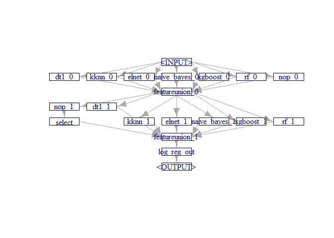

```r
level0 = gunion(
  list(
    po("learner_cv", id = "dt1_0", learner = dt, resampling.method = "cv", resampling.folds = 3L),
    po("learner_cv", id = "kknn_0", learner = kknn, resampling.method = "cv", resampling.folds = 3L),
    po("learner_cv", id = "elnet_0", learner = elnet, resampling.method = "cv", resampling.folds = 3L),
    po("learner_cv", id = "naive_bayes_0", learner = naive_bayes, resampling.method = "cv", resampling.folds = 3L),
    po("learner_cv", id = "xgboost_0", learner = xgboost, resampling.method = "cv", resampling.folds = 3L),
    po("learner_cv", id = "rf_0", learner = rf, resampling.method = "cv", resampling.folds = 3L),
    po("nop", id = "nop_0")
  )
) %>>% po("featureunion", id = "featureunion_0")
level1 = gunion(
  list(
    po("learner_cv", id = "dt1_1", learner = dt, resampling.method = "cv", resampling.folds = 3L),
    po("learner_cv", id = "kknn_1", learner = kknn, resampling.method = "cv", resampling.folds = 3L),
    po("learner_cv", id = "elnet_1", learner = elnet, resampling.method = "cv", resampling.folds = 3L),
    po("learner_cv", id = "naive_bayes_1", learner = naive_bayes, resampling.method = "cv", resampling.folds = 3L),
    po("learner_cv", id = "xgboost_1", learner = xgboost, resampling.method = "cv", resampling.folds = 3L),
    po("learner_cv", id = "rf_1", learner = rf, resampling.method = "cv", resampling.folds = 3L),
    po("nop", id = "nop_1") %>>% po("select", selector = selector_name(task$feature_names))
  )
) %>>% po("featureunion", id = "featureunion_1")
level2 = lrn("classif.log_reg", id = "log_reg_out")
level2$predict_type = "prob"

ensemble_multilayer_cv_pass = as_learner(level0 %>>% level1 %>>% level2)
ensemble_multilayer_cv_pass$id = "Multilayer Stacked Ensemble 3-fold CV + Orig Features"
ensemble_multilayer_cv_pass$graph$plot()
```

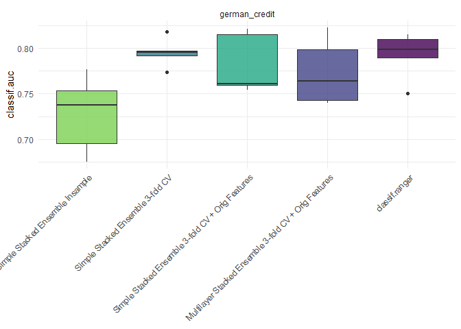

```r
bg = benchmark_grid(task, list(ensemble, ensemble_cv, ensemble_cv_pass, ensemble_multilayer_cv_pass, rf), resampling)
b = benchmark(bg)
autoplot(b, measure = msr("classif.auc"))
```

```r
# Sometimes beating a random forest baseline can be really difficult.
```

# Summary

We implemented Greedy Ensemble Selection from scratch. Then we look at how to implement various ways of stacked ensemblings and benchmarked them.